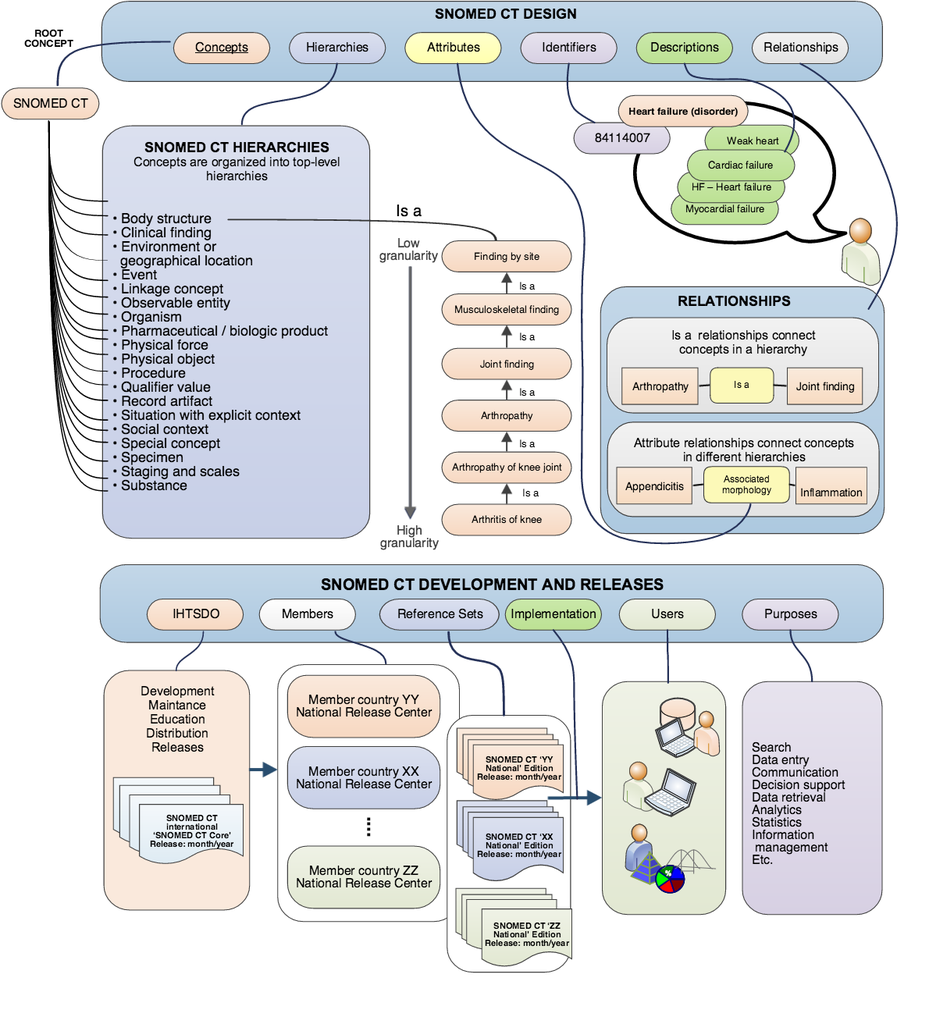

```python
from IPython.display import Image
Image(filename='./images/SNOMEDOverview.png')
```

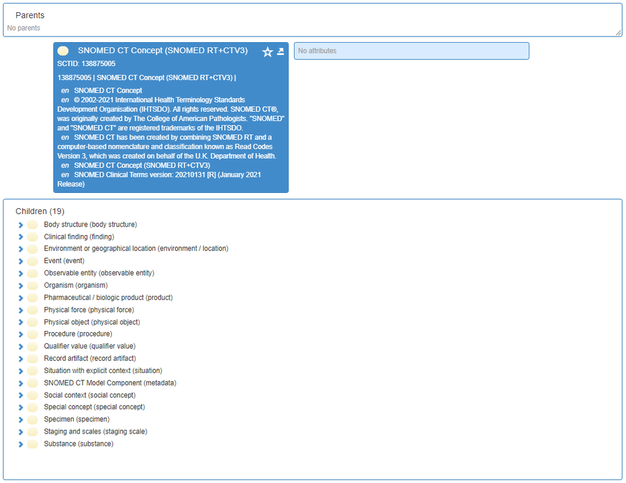

```python
Image(filename='./images/SnomedCT_Concept.png')
```

| SNOMED CT Concept (SNOMED RT+CTV3) | SCTID: 138875005, PRIMITIVE, Active | Descendants Count, Stated: 354447 concepts | *Proportion* `100`% |
| --- | --- | --- | --- |
| Body structure (body structure) | SCTID: 123037004, PRIMITIVE, Active | Descendants Count, Stated: 39759 concepts | 11.22% |
| Clinical finding (finding) | SCTID: 404684003, PRIMITIVE, Active | Descendants Count, Stated: 114492 concepts | 32.30% |
| Environment or geographical location (environment / location) | SCTID: 308916002, PRIMITIVE, Active | Descendants Count, Stated: 1836 concepts | 0.52% |
| Event (event) | SCTID: 272379006, PRIMITIVE, Active | Descendants Count, Stated: 3210 concepts | 0.91% |
| Observable entity (observable entity) | SCTID: 363787002, PRIMITIVE, Active | Descendants Count, Stated: 9383 concepts | 2.65% |
| Organism (organism) | SCTID: 410607006, PRIMITIVE, Active | Descendants Count, Stated: 35230 concepts | 9.94% |
| Pharmaceutical / biologic product (product) | SCTID: 373873005, PRIMITIVE, Active | Descendants Count, Stated: 22848 concepts | 6.45% |
| Physical force (physical force) | SCTID: 78621006, PRIMITIVE, Active | Descendants Count, Stated: 170 concepts | 0.05% |
| Physical object (physical object) | SCTID: 260787004, PRIMITIVE, Active | Descendants Count, Stated: 15752 concepts | 4.43% |
| Procedure (procedure) | SCTID: 71388002, PRIMITIVE, Active | Descendants Count, Stated: 58444 concepts | 16.49% |
| Qualifier value (qualifier value) | SCTID: 362981000, PRIMITIVE, Active | Descendants Count, Stated: 11027 concepts | 3.11% |
| Record artifact (record artifact) | SCTID: 419891008, PRIMITIVE, Active | Descendants Count, Stated: 501 concepts | 0.14% |
| Situation with explicit context (situation) | SCTID: 243796009, PRIMITIVE, Active | Descendants Count, Stated: 4709 concepts | 1.33% |
| SNOMED CT Model Component (metadata) | SCTID: 900000000000441003, PRIMITIVE, Active | Descendants Count, Stated: 1801 concepts | 0.51% |
| Social context (social concept) | SCTID: 48176007, PRIMITIVE, Active | Descendants Count, Stated: 4422 concepts | 1.25% |
| Special concept (special concept) | SCTID: 370115009, PRIMITIVE, Active | Descendants Count, Stated: 635 concepts | 0.18% |
| Specimen (specimen) | SCTID: 123038009, PRIMITIVE, Active | Descendants Count, Stated: 1716 concepts | 0.48% |
| Staging and scales (staging scale) | SCTID: 254291000, PRIMITIVE, Active | Descendants Count, Stated: 1595 concepts | 0.45% |
| Substance (substance) | SCTID: 105590001, PRIMITIVE, Active | Descendants Count, Stated: 26913 concepts | 7.59% |

### relationship:

Eine Assoziation zwischen einem Quellkonzept und einem Zielkonzept.

Jede Beziehung wird durch eine eigene Zeile in der Beziehungsdatei dargestellt.

Jede Beziehung hat einen eindeutigen Bezeichner (identifier) und enthält Spalten, die den Beziehungstyp und die Konzepte, die miteinander in Beziehung stehen (sourceId und destinationId), identifizieren.

Jede Beziehung liefert definierende Informationen über das Quellkonzept.

#### Beispiel

Quelle, Typ und Ziel einer der Beziehungen für das Konzept 74400008 | Appendicitis (disorder) | lauten wie folgt:

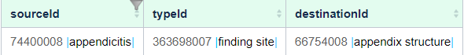

```python
Image(filename='./images/relationship1.png')
```

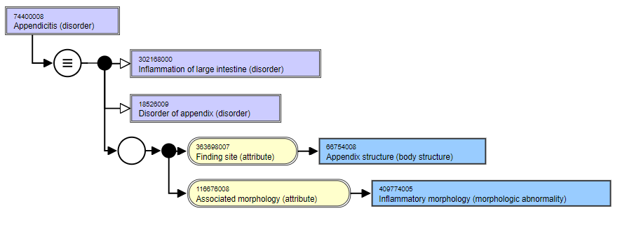

```python
Image(filename='./images/relationship2.png')
```

### Spezifikation der Beziehungsdaten:

Die Beziehungsdatei enthält eine Beziehung pro Zeile. Jede Beziehung ist von einem bestimmten Typ und hat ein Quellkonzept und ein Zielkonzept. Ein Beispiel für eine Beziehung ist unten angegeben:

##### 371883000 |Outpatient procedure| 116680003 |Is a| 71388002 |Procedure|

| 371883000 \|Outpatient procedure\| | ist das Quellkonzept |
| --- | --- |
| 116680003 \|Is a\| | ist das Beziehungstyp-Konzept |
| 71388002 \|Procedure\| | ist das Zielkonzept |

[output not shown]

- Zu jedem Zeitpunkt ist nur ein Beziehungsdatensatz mit demselben id-Feld aktuell. Der aktuelle Datensatz ist derjenige mit der jüngsten effectiveTime vor oder gleich dem betrachteten Zeitpunkt.
- Wenn das aktive Feld dieses Datensatzes false('0') ist, dann ist die Beziehung zu diesem Zeitpunkt inactive. Wenn das aktive Feld true('1') ist, dann besteht eine Beziehung zwischen den SNOMED CT-Konzepten, die durch sourceId und destinationId identifiziert werden.
- Die Felder sourceId, destinationId, relationshipGroup, typeId, characteristicTypeId und modifierId ändern sich nicht zwischen zwei Zeilen mit derselben id, d. h. sie sind unveränderlich. Wenn eine Änderung an einem dieser Felder erforderlich ist, wird die aktuelle Zeile deaktiviert (durch Anhängen einer Zeile mit der gleichen id und dem auf 'false' gesetzten Feld "active") und eine neue Zeile mit einer neuen id angehängt.
- Das relationshipGroup-Feld wird verwendet, um Beziehungen mit demselben sourceId-Feld in einem oder mehreren logischen Sets zu gruppieren. Eine Beziehung mit einem relationshipGroup-Feldwert von '0' wird als nicht gruppiert betrachtet. Alle Beziehungen mit der gleichen sourceId und einer relationshipGroup ungleich Null werden als logisch gruppiert betrachtet.
- Das relationshipGroup-Feld ist eine Ganzzahl ohne Vorzeichen (unsigned Integer) und nicht auf einen einstelligen Wert beschränkt. Es gibt keine Garantie, dass sie der Reihe nach zugewiesen werden, und die Werte sind nicht konzeptübergreifend eindeutig.

### mapping

##### Der Prozess der Konvertierung von Daten von einem Codesystem, einer Klassifizierung oder Terminologie in ein anderes Codesystem, eine andere Klassifizierung oder Terminologie.

- Der Mapping-Prozess umfasst die Erstellung und Pflege von Ressourcen, die für die Konvertierung von Daten verwendet werden.
- SNOMED CT Mapping-Ressourcen werden als "mapping reference sets" verteilt.

### mapping reference set

##### Ein Referenzsatz, der den Prozess der Zuordnung von Daten von einem Codesystem, einer Klassifikation oder Terminologie zu einem anderen Codesystem, einer Klassifikation oder Terminologie unterstützen soll.

Es gibt mehrere Arten von Mapping-Referenzsätzen, die jeweils unterschiedliche Arten von Mapping unterstützen.

- **Simple Map Reference Sets**  
  Ein `900000000000496009 |Simple map reference set|` ermöglicht die Darstellung von einfachen Zuordnungen zwischen SNOMED CT-Konzepten und Werten in anderen Kodierungssystemen. Es gibt keine Einschränkungen in Bezug auf die Anzahl der unterstützten Kodierschemata, die Anzahl der Kodes innerhalb eines bestimmten Schemas, die durch ein einzelnes SNOMED CT-Konzept abgebildet werden, oder die Anzahl der SNOMED CT-Konzepte, die auf einen bestimmten Kode abgebildet werden. Diese Art von Referenzsatz ist jedoch in der Regel nur dann geeignet, wenn es eine enge "Eins-zu-eins"-Abbildung zwischen SNOMED CT-Konzepten und kodierten Werten in einem anderen Kodesystem gibt.
- **Complex and Extended Map Reference Sets**  
  unterstützen Maps, wenn zusätzliche Informationen benötigt werden, um die korrekte Zuordnung von SNOMED CT zu einer statistischen Klassifikation wie ICD-10 zu bestimmen.  
  Ein `447250001 |Complex map type reference set|` ermöglicht die Darstellung von Maps, bei denen jedes SNOMED CT-Konzept auf einen oder mehrere Codes in einem Zielschema *(target scheme)* abgebildet werden kann. Der Typ des Referenzsatzes unterstützt den allgemeinen Satz von Abbildungsdaten, die erforderlich sind, um zur Laufzeit einen Zielcode aus einer Reihe alternativer Codes auswählen zu können. Er unterstützt die Auswahl des Zielcodes, indem er die Aufnahme von maschinenlesbaren Regeln and/or menschenlesbaren Hinweisen ermöglicht. Ein `609331003 |Extended map type reference set|` fügt ein zusätzliches Feld hinzu, um die Kategorisierung von Maps zu ermöglichen.
- **Map Correlation and Origin Reference Sets**  
  unterstützen Mappings zu oder von einem anderen Codesystem, wobei eine zusätzliche Anforderung besteht, Fälle zu erfassen, in denen ein Code in einem Codesystem speziell zu dem Zweck hinzugefügt wurde, ein Map aus dem Codesystem zu ermöglichen, in dem der Code seinen Ursprung hat.
- **Code to Expression Reference Sets**  
  unterstützen Zuordnungen aus anderen Codesystemen in Fällen, in denen einige oder alle Quellcodes durch einen nachkoordinierten Ausdruck dargestellt werden müssen.  
  Das `705109006|Code to expression type reference set|` dient dazu, Assoziationen zwischen Codes in einem anderen Codesystem (other-codes) und SNOMED CT-Konzepten zu ermöglichen, wobei die folgenden Einschränkungen gelten:
  1. Einige der sonstigen Codes (nicht SNOMED CT-Codes) können nicht auf ein einzelnes SNOMED CT-Konzept abgebildet werden.
  2. Lizenzbedingungen (oder andere Erwägungen) verhindern das Hinzufügen neuer SNOMED CT-Konzepte, die die gleiche Bedeutung wie die anderen Codes darstellen.
  3. Die anderen Codes können unter Verwendung des SNOMED-Konzeptmodells logisch definiert werden, um die gleiche Bedeutung (ausreichend definiert) oder eine ähnliche, jedoch weniger spezifische Bedeutung (primitiv) zu repräsentieren.
  4. Andere Anforderungen, die denen für das Mapping ähnlich sind, können ebenfalls gelten:
     - Ein Hinweis auf den Grad der Korrelation zwischen dem anderen Code und dem SNOMED CT-Ausdruck.
     - Ein Hinweis darauf, ob der andere Code vor einer Einzelkonzeptdarstellung dieser Bedeutung in SNOMED CT erstellt wurde oder ob die Einzelkonzeptdarstellung in SNOMED CT der Erstellung der Assoziation vorausging.

## Concept:

- Konzepte sind mit Beschreibungen "descriptions" verknüpft, die menschenlesbare Begriffe zur Beschreibung des Konzepts enthalten.
- Konzept, in seiner allgemeineren Verwendung im Wörterbuch, bezieht sich auf eine Idee oder auf eine Klasse von Entitäten der realen Welt. Bei der Arbeit mit SNOMED CT werden die Wörter "Idee" oder "Bedeutung" anstelle dieser allgemeineren Verwendung von Konzept vorgeschlagen.
- Um Klarheit zu schaffen, wenn Sie sich auf den Identifikator eines SNOMED CT-Konzepts beziehen, sollten Sie sich ausdrücklich auf "concept identifier", "concept id" oder den "Code" beziehen, anstatt das Wort Konzept zu verwenden.

### description:

- Jede Beschreibung wird durch eine eigene Zeile in der Beschreibungsdatei dargestellt.
- Jede Beschreibung hat einen eindeutigen Bezeichner (identifier) und verbindet ein Konzept mit einem Begriff eines bestimmten Beschreibungstyps (description type).
- Alle Konzepte haben Beschreibungen mit Beschreibungstypen voll spezifiziertem Namen und Synonym. Andere Beschreibungstypen können definiert werden und können auf einige Konzepte angewendet werden.

### description type:

Ein Hinweis auf die beabsichtigte Verwendung eines Begriffs einer SNOMED CT-Beschreibung bei Anwendung auf das zugehörige Konzept.

- 900000000000003001 |Fully specified name| Eine Beschreibung, die die Bedeutung eines Konzepts in einer Weise darstellt, die eindeutig und unabhängig vom Kontext ist, in dem es verwendet wird.
- 900000000000013009 |Synonym| Ein Wort oder eine Phrase, die die Bedeutung eines SNOMED CT-Konzepts in einer bestimmten Sprache (ISO639-1 language code) ausdrückt.
- 900000000000550004 |Definition| Eine erzählende Texterklärung der Bedeutung eines Konzepts, die die maximal zulässige Länge für einen "vollständig spezifizierten Namen" überschreiten kann.

### destination concept:

#### Ein Konzept, das den Wert einer Beziehung (relationship) angibt.

- Das "destination concept" wird durch "destinationId" in der Beziehung identifiziert.
- Das "destination concept" stellt den Wert eines definierenden Merkmals des Quellkonzepts (source concept) dar.

### destinationId:

Ein Feld in der Beziehungsfreigabedatei, das einen SNOMED CT-Bezeichner (identifier) enthält, der das Zielkonzept oder den Attributwert der zugehörigen Beziehung darstellt.

### attribute:

- Ein Merkmal der Bedeutung eines Begriffs (concept) oder der Art einer Verfeinerung.
- Einem Attribut wird ein Wert (attribute value pair) zugewiesen, wenn es in der Definition eines Konzepts oder in einem nachkoordinierten Ausdruck verwendet wird.
- Die Attribute, die in Definitionen oder Verfeinerungen verwendet werden können, werden durch ein Konzept dargestellt, das Subtypen des Konzepts 410662002 |Concept model attribute (attribute)|sind.
- parents von 410662002 |Concept model attribute (attribute)|:  
  138875005 | SNOMED CT Concept (SNOMED RT+CTV3) | > 900000000000441003 | SNOMED CT Model > 106237007 | Linkage concept (linkage concept) |> 246061005 | Attribute (attribute) | > 410662002 |Concept model attribute (attribute)| > ...

#### Beispiel

- Das Attribut 116676008 |Associated morphology| ist eines der Attribute, die auf Konzepte im Bereich 404684003 |Clinical finding| angewendet werden können; und seine Subtypen.
- sein Bereich umfasst 49755003 Morphologically abnormal structurer (morphologic abnormality)| und seine Subtypen.

### attribute value pair:

- Eine Kombination aus einem Attributnamen und einem Attributwert, die zur Angabe eines definierenden Merkmals eines Konzepts verwendet wird.
- Der Attributname identifiziert den Typ der Information und der Attributwert liefert einen Wert.
- Ein Attributwertepaar kann ein definierendes Merkmal eines Konzepts oder eine Ausdrucksverfeinerung darstellen.
- In der Beziehungsdatei wird der Attributname durch die relationship.typeId und der Attributwert durch die relationship.destinationId dargestellt.

### Attributgruppe

- Eine Assoziation zwischen einer Menge von Attributwertepaaren, die bewirkt, dass sie innerhalb einer Konzeptdefinition oder eines nachkoordinierten Ausdrucks gemeinsam betrachtet werden.
- Wenn eine Attributgruppe als eine Gruppe von Definitionsbeziehungen dargestellt wird, wird sie gewöhnlich als Beziehungsgruppe bezeichnet. #### Beispiel: "Cholecystectomy with exploration of common duct" hat zwei verschiedene Attributgruppen.  
  Wenn diese Attribute nicht gruppiert wären, würde dieses Verfahren fälschlicherweise als Untertyp von "Excision of common bile duct" klassifiziert werden.

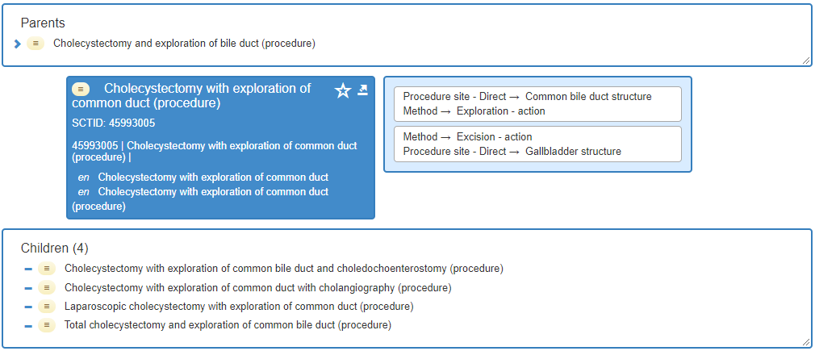

```python
Image(filename='./images/Attributgruppe.png')
```

## identifier

- Jede SNOMED CT-Komponente wird durch einen SNOMED CT-Identifier (SCTID) identifiziert, der wie folgt definiert ist:  
  Ein eindeutiger ganzzahliger Bezeichner, der auf jede SNOMED CT-Komponente (Concept, Description, or Relationship) angewendet wird.
- Jeder SNOMED CT-Identifikator (SCTID) enthält einen Item-Identifikator, ein check-digit, einen Partitions Identifikator und, abhängig vom Partitions-Identifikator, kann er auch einen Namespace-Identifikator enthalten.
- Jedes Referenzsatzmitglied wird durch einen Universally Unique Identifier (UUID) identifiziert, der wie folgt definiert ist:  
  Eine **128-Bit-Ganzzahl**, die zur eindeutigen Identifizierung von Informationen in Computersystemen verwendet wird
- Universell eindeutige Bezeichner werden durch allgemein verfügbare **Algorithmen** erzeugt. Sie werden verwendet, um Informationen in Computersystemen weltweit zu identifizieren.
- In SNOMED CT werden universell eindeutige Bezeichner zur eindeutigen Identifizierung von Referenzsatzmitgliedern verwendet. Da universell eindeutige Bezeichner eindeutig sind, ist es unnötig, die Vergabe von Bezeichnern für die Tausenden von Referenzsatzmitgliedern zu verfolgen, die in einigen Implementierungen benötigt werden.
- In den SNOMED CT-Release-Dateien werden die universell eindeutigen Identifikatoren als Zeichenkette dargestellt, die einer kanonischen Standardform (canonical form) folgt - einer Zeichenkette mit 36 characters, die 32 Hexadezimalziffern und vier Bindestriche enthält. Die Hexadezimalziffern sind in fünf Gruppen angeordnet, die durch die Bindestriche getrennt sind. Die erste Gruppe enthält 8 Hexadezimalziffern, die letzte Gruppe enthält 12 und jede der drei anderen Gruppen enthält 4. Das Gesamtmuster (overall pattern) ist also 8-4-4-4-12.

### term:

Eine vom Menschen lesbare Phrase, die ein Konzept benennt oder beschreibt.

- Ein Begriff ist eine der Eigenschaften einer Beschreibung.
- Andere Eigenschaften einer Beschreibung verknüpfen den Begriff mit einem identifizierten Konzept und geben die Art der Beschreibung an.